# Water and Economy Xiaojing Ni - Deep Learning for TS

Author

Xiaojing Ni

```python
import numpy as np
import pandas as pd
import matplotlib.pyplot as plt
import keras
from keras.models import Sequential
from sklearn.preprocessing import MinMaxScaler
from sklearn.metrics import mean_squared_error
from keras.layers import Dense, SimpleRNN,LSTM,GRU
```

```
2023-05-01 21:11:00.472594: I tensorflow/core/platform/cpu_feature_guard.cc:182] This TensorFlow binary is optimized to use available CPU instructions in performance-critical operations.
To enable the following instructions: AVX2 AVX512F AVX512_VNNI FMA, in other operations, rebuild TensorFlow with the appropriate compiler flags.
```

## Data processing

### Monthly discharge

```python
## read data
daily_discharge = pd.read_csv("./data/clean_discharge.csv")
daily_discharge = daily_discharge.rename(columns={"discharge.date": "date", "discharge.discharge": "discharge"})
daily_discharge['date'] = pd.to_datetime(daily_discharge['date'])
```

```python
daily_discharge
```

|  | date | discharge |
| --- | --- | --- |
| 0 | 1970-01-01 | 850.0 |
| 1 | 1970-01-02 | 850.0 |
| 2 | 1970-01-03 | 800.0 |
| 3 | 1970-01-04 | 750.0 |
| 4 | 1970-01-05 | 750.0 |
| ... | ... | ... |
| 19398 | 2023-02-10 | 28800.0 |
| 19399 | 2023-02-11 | 26100.0 |
| 19400 | 2023-02-12 | 17800.0 |
| 19401 | 2023-02-13 | 11000.0 |
| 19402 | 2023-02-14 | 8850.0 |

19403 rows × 2 columns

```python
daily_discharge.info()
```

```
<class 'pandas.core.frame.DataFrame'>
RangeIndex: 19403 entries, 0 to 19402
Data columns (total 2 columns):
 #   Column     Non-Null Count  Dtype
---  ------     --------------  -----
 0   date       19403 non-null  datetime64[ns]
 1   discharge  19394 non-null  float64
dtypes: datetime64[ns](1), float64(1)
memory usage: 303.3 KB
```

```python
## log transformation
daily_discharge['log_discharge'] = np.log(daily_discharge['discharge'])

## filter 1980-2022
mask = (daily_discharge['date'] > '1980-01-01') & (daily_discharge['date'] <= '2022-12-31')

discharge1980 = daily_discharge.loc[mask]

# ## convert to monthly
# monthly_logmean = discharge1980.groupby(pd.PeriodIndex(discharge1980['date'], freq="M"))['log_discharge'].mean()

# monthly_logmean.index = monthly_logmean.index.strftime('%Y-%m')
# monthly_logmean_df = monthly_logmean.to_frame().reset_index()
# print(monthly_logmean_df.shape)
```

```python
discharge1980.info()
discharge1980.head()
```

```
<class 'pandas.core.frame.DataFrame'>
Int64Index: 15705 entries, 3653 to 19357
Data columns (total 3 columns):
 #   Column         Non-Null Count  Dtype
---  ------         --------------  -----
 0   date           15705 non-null  datetime64[ns]
 1   discharge      15698 non-null  float64
 2   log_discharge  15698 non-null  float64
dtypes: datetime64[ns](1), float64(2)
memory usage: 490.8 KB
```

|  | date | discharge | log_discharge |
| --- | --- | --- | --- |
| 3653 | 1980-01-02 | 7420.0 | 8.911934 |
| 3654 | 1980-01-03 | 5770.0 | 8.660427 |
| 3655 | 1980-01-04 | 4590.0 | 8.431635 |
| 3656 | 1980-01-05 | 3690.0 | 8.213382 |
| 3657 | 1980-01-06 | 3330.0 | 8.110728 |

```python
X = np.array(discharge1980["log_discharge"].values.astype('float32')).reshape(discharge1980.shape[0],1)
print(X.shape)
```

```
(15705, 1)
```

## Visualize

```python
import plotly.io as pio
pio.renderers.default = "plotly_mimetype+notebook_connected"
import plotly.express as px

# UTILITY
def plotly_line_plot(t,y,title="Plot",x_label="t: time (months)",y_label="y(t): Response variable"):

    # GENERATE PLOTLY FIGURE
    fig = px.line(x=t[0],y=y[0], title=title, render_mode='SVG')
    # IMPORTANT: SVG FIXES RENDER ISSUES WITH SAD FACE
    # https://community.plotly.com/t/plotly-express-line-charts-are-not-shown/39715

    # ADD MORE
    for i in range(1,len(y)):
        if len(t[i])==1:
            #print(t[i],y[i])
            fig.add_scatter(x=t[i],y=y[i])
        else:
            fig.add_scatter(x=t[i],y=y[i], mode='lines')

    fig.update_layout(
        xaxis_title=x_label,
        yaxis_title=y_label,
        template="plotly_white",
        showlegend=False
    )
    fig.show()
```

```python
# SINGLE SERIES
t=[*range(0,len(X))]
plotly_line_plot([t],[X[:,0]],title="Daily log stream discharge since 1980-01")
```

[interactive chart not shown]

## Test-train split data

first 80% of the data is training, laster 20% of the data is testing

```python
### Utility function:
# Parameter split_percent defines the ratio of training examples
def get_train_test(data, split_percent=0.8):
    scaler = MinMaxScaler(feature_range=(0, 1))
    data = scaler.fit_transform(data).flatten()
    n = len(data)
    # Point for splitting data into train and test
    split = int(n*split_percent)
    train_data = data[range(split)]
    test_data = data[split:]
    return train_data, test_data, data

train_data, test_data, data = get_train_test(X)

print(train_data.shape)
print(test_data.shape)
```

```
(12564,)
(3141,)
```

```python
t1=[*range(0,len(train_data))]
t2=len(train_data)+np.array([*range(0,len(test_data))])
plotly_line_plot([t1,t2],[train_data,test_data],title="Daily log stream discharge since 1980-01")
```

[interactive chart not shown]

## Re-format data into required shape

```python
# PREPARE THE INPUT X AND TARGET Y
def get_XY(dat, time_steps,plot_data_partition=False):
    global X_ind,X,Y_ind,Y #use for plotting later

    # INDICES OF TARGET ARRAY
    # Y_ind [  12   24   36   48 ..]; print(np.arange(1,12,1)); exit()
    Y_ind = np.arange(time_steps, len(dat), time_steps); #print(Y_ind); exit()
    Y = dat[Y_ind]

    # PREPARE X
    rows_x = len(Y)
    X_ind=[*range(time_steps*rows_x)]
    del X_ind[::time_steps] #if time_steps=10 remove every 10th entry
    X = dat[X_ind];

    #PLOT
    if(plot_data_partition):
        plt.figure(figsize=(15, 6), dpi=80)
        plt.plot(Y_ind, Y,'o',X_ind, X,'-'); plt.show();

    #RESHAPE INTO KERAS FORMAT
    X1 = np.reshape(X, (rows_x, time_steps-1, 1))
    # print([*X_ind]); print(X1); print(X1.shape,Y.shape); exit()

    return X1, Y


#PARTITION DATA, to monthly
p=31 # simpilar to AR(p) given time_steps data points, predict time_steps+1 point (make prediction one month in future)

testX, testY = get_XY(test_data, p)
trainX, trainY = get_XY(train_data, p)
```

```python
print(testX.shape,testY.shape)
print(trainX.shape,trainY.shape)
print(type(trainX))
```

```
(101, 30, 1) (101,)
(405, 30, 1) (405,)
<class 'numpy.ndarray'>
```

## Simple RNN

### Model and training parameters

```python
#USER PARAM
recurrent_hidden_units=3
epochs=400
f_batch=0.2    #fraction used for batch size
optimizer="RMSprop"
# max_features = 10000    #DEFINES SIZE OF VOCBULARY TO USE
# maxlen       = 250      #CUTOFF REVIEWS maxlen 20 WORDS)
batch_size   = 1000
verbose      = 0
embed_dim    = 8        #DIMENSION OF EMBEDING SPACE (SIZE OF VECTOR FOR EACH WORD)
lr           = 0.001    #LEARNING RATE
validation_split=0.2
```

### Create model with l2 regulation

```python
from tensorflow.keras import regularizers


#CREATE MODEL
model = Sequential()
#COMMENT/UNCOMMENT TO USE RNN, LSTM,GRU
# model.add(LSTM(
model.add(SimpleRNN(
# model.add(GRU(
recurrent_hidden_units,
return_sequences=False,
input_shape=(trainX.shape[1],trainX.shape[2]),
# recurrent_dropout=0.8,
recurrent_regularizer=regularizers.L2(1e-1), ##L2 regulation
activation='tanh')
          )

#NEED TO TAKE THE OUTPUT RNN AND CONVERT TO SCALAR
model.add(Dense(units=1, activation='linear'))

# COMPILE THE MODEL
model.compile(loss='MeanSquaredError', optimizer=optimizer)
model.summary()
```

```
Model: "sequential"
```

```
_________________________________________________________________
```

```
 Layer (type)                Output Shape              Param #
```

```
 simple_rnn (SimpleRNN)      (None, 3)                 15
```

```
 dense (Dense)               (None, 1)                 4
```

```
Total params: 19
```

```
Trainable params: 19
```

```
Non-trainable params: 0
```

```
_________________________________________________________________
```

### Train model

```python
#TRAIN MODEL
history = model.fit(
trainX, trainY,
epochs=epochs,
batch_size=int(f_batch*trainX.shape[0]),
validation_split=validation_split,  # BEING "SLOPPY WITH CROSS VALIDATION" HERE FOR TIME-SERIES
verbose=0)
```

### Visualize fitting history

```
(405, 30, 1) (405,) (405,) (101, 30, 1) (101,) (101,)
(405,) (405,)
0.0017565492
0.001448677
Train MSE = 0.00176 RMSE = 0.04191
Test MSE = 0.00145 RMSE = 0.03806
```

[interactive chart not shown]

[output not shown]

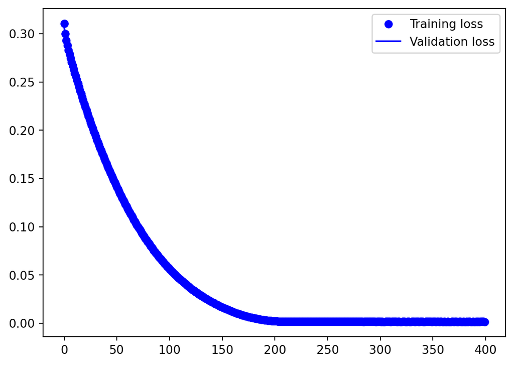

```python
#HISTORY PLOT
epochs_steps = [*range(0, len(history.history['loss']))]

# MAKE PREDICTIONS
train_predict = model.predict(trainX).squeeze()
test_predict = model.predict(testX).squeeze()
print(trainX.shape, train_predict.shape,trainY.shape,testX.shape, test_predict.shape,testY.shape)

#COMPUTE RMSE
print(trainY.shape, train_predict.shape)
train_rmse = np.sqrt(mean_squared_error(trainY, train_predict))
test_rmse = np.sqrt(mean_squared_error(testY, test_predict))
print(np.mean((trainY-train_predict)**2.0))
print(np.mean((testY-test_predict)**2.0))

print('Train MSE = %.5f RMSE = %.5f' % (train_rmse**2.0,train_rmse))
print('Test MSE = %.5f RMSE = %.5f' % (test_rmse**2.0,test_rmse))

# PLOTLY PLOT
plotly_line_plot([epochs_steps,epochs_steps],[history.history['loss'],history.history['val_loss']],title="Training epoch vs errors",x_label="training epochs",y_label="loss (MSE)")

print(history.history['loss'])
# SIMPLE PLOT
plt.figure()
plt.plot(epochs_steps, history.history['loss'], 'bo', label='Training loss')
plt.plot(epochs_steps, history.history['val_loss'], 'b', label='Validation loss')
plt.legend()
```

### Visualize parity plot

```python
# GET DATA
# GENERATE PLOTLY FIGURE

fig = px.scatter(x=trainY,y=train_predict,height=600,width=800)
fig.add_scatter(x=testY,y=test_predict,mode="markers")
fig.add_scatter(x=trainY,y=trainY, mode='lines')

fig.update_layout(
    xaxis_title="y_pred",
    yaxis_title="y_data",
    template="plotly_white",
    showlegend=False
)

fig.show()
```

[interactive chart not shown]

### Visualize predictions-2

```
(12150,) (405,)
```

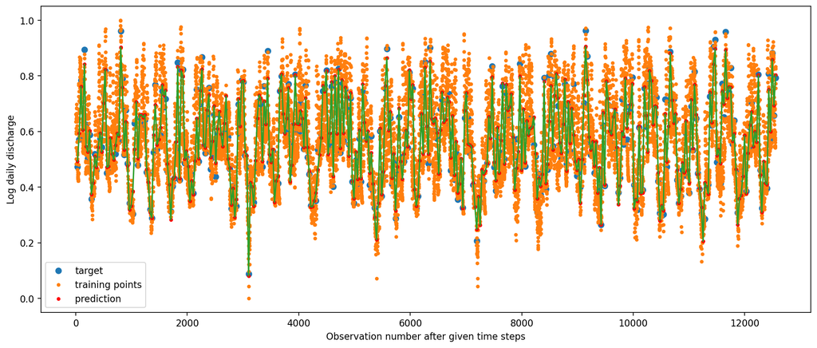

```python
# PLOT THE RESULT
def plot_result(trainY, testY, train_predict, test_predict):
    plt.figure(figsize=(15, 6), dpi=80)
    #ORIGINAL DATA
    print(X.shape,Y.shape)
    plt.plot(Y_ind, Y,'o', label='target')
    plt.plot(X_ind, X,'.', label='training points');
    plt.plot(Y_ind, train_predict,'r.', label='prediction');
    plt.plot(Y_ind, train_predict,'-');
    plt.legend()
    plt.xlabel('Observation number after given time steps')
    plt.ylabel('Log daily discharge')
    #plt.title('Actual and Predicted Values. The Red Line Separates The Training And Test Examples')
    plt.show()
plot_result(trainY, testY, train_predict, test_predict)
```

### Model with no regulation

```python
#CREATE MODEL
model = Sequential()
#COMMENT/UNCOMMENT TO USE RNN, LSTM,GRU
# model.add(LSTM(
model.add(SimpleRNN(
# model.add(GRU(
recurrent_hidden_units,
return_sequences=False,
input_shape=(trainX.shape[1],trainX.shape[2]),
# recurrent_dropout=0.8,
#recurrent_regularizer=regularizers.L2(1e-1), ##L2 regulation
activation='tanh')
          )

#NEED TO TAKE THE OUTPUT RNN AND CONVERT TO SCALAR
model.add(Dense(units=1, activation='linear'))

# COMPILE THE MODEL
model.compile(loss='MeanSquaredError', optimizer=optimizer)
model.summary()
```

```
Model: "sequential_1"
```

```
_________________________________________________________________
```

```
 Layer (type)                Output Shape              Param #
```

```
 simple_rnn_1 (SimpleRNN)    (None, 3)                 15
```

```
 dense_1 (Dense)             (None, 1)                 4
```

```
Total params: 19
```

```
Trainable params: 19
```

```
Non-trainable params: 0
```

```
_________________________________________________________________
```

### Train model

```python
#TRAIN MODEL
history = model.fit(
trainX, trainY,
epochs=epochs,
batch_size=int(f_batch*trainX.shape[0]),
validation_split=validation_split,  # BEING "SLOPPY WITH CROSS VALIDATION" HERE FOR TIME-SERIES
verbose=0)
```

### Visualize fitting history

```
(405, 30, 1) (405,) (405,) (101, 30, 1) (101,) (101,)
(405,) (405,)
0.0027458135
0.002553787
Train MSE = 0.00275 RMSE = 0.05240
Test MSE = 0.00255 RMSE = 0.05054
```

[interactive chart not shown]

[output not shown]

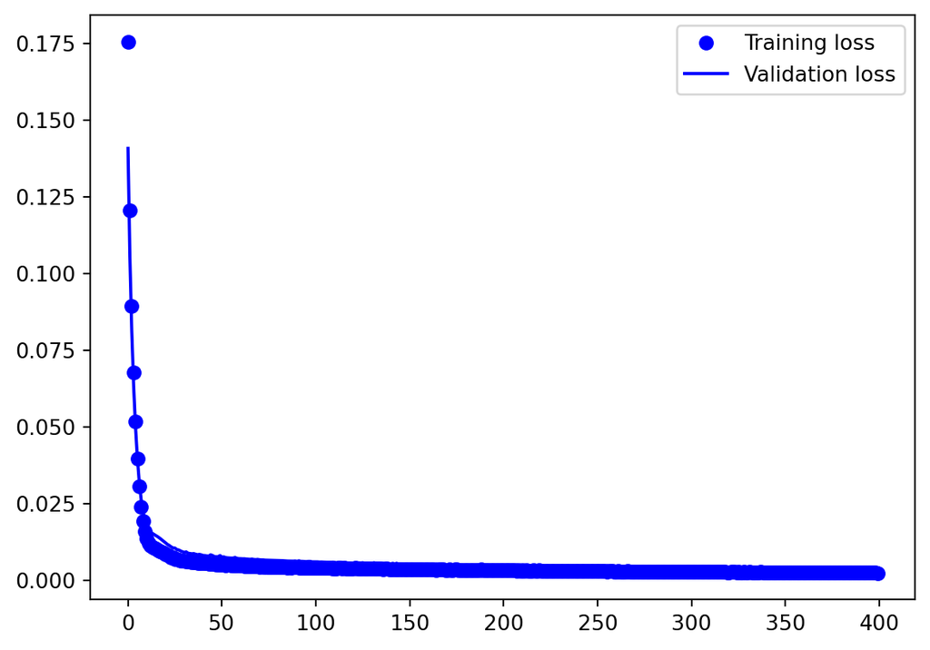

```python
#HISTORY PLOT
epochs_steps = [*range(0, len(history.history['loss']))]

# MAKE PREDICTIONS
train_predict = model.predict(trainX).squeeze()
test_predict = model.predict(testX).squeeze()
print(trainX.shape, train_predict.shape,trainY.shape,testX.shape, test_predict.shape,testY.shape)

#COMPUTE RMSE
print(trainY.shape, train_predict.shape)
train_rmse = np.sqrt(mean_squared_error(trainY, train_predict))
test_rmse = np.sqrt(mean_squared_error(testY, test_predict))
print(np.mean((trainY-train_predict)**2.0))
print(np.mean((testY-test_predict)**2.0))

print('Train MSE = %.5f RMSE = %.5f' % (train_rmse**2.0,train_rmse))
print('Test MSE = %.5f RMSE = %.5f' % (test_rmse**2.0,test_rmse))

# PLOTLY PLOT
plotly_line_plot([epochs_steps,epochs_steps],[history.history['loss'],history.history['val_loss']],title="Training epoch vs errors",x_label="training epochs",y_label="loss (MSE)")

print(history.history['loss'])
# SIMPLE PLOT
plt.figure()
plt.plot(epochs_steps, history.history['loss'], 'bo', label='Training loss')
plt.plot(epochs_steps, history.history['val_loss'], 'b', label='Validation loss')
plt.legend()
```

### Visualize parity plot

```python
# GET DATA
# GENERATE PLOTLY FIGURE

fig = px.scatter(x=trainY,y=train_predict,height=600,width=800)
fig.add_scatter(x=testY,y=test_predict,mode="markers")
fig.add_scatter(x=trainY,y=trainY, mode='lines')

fig.update_layout(
    xaxis_title="y_pred",
    yaxis_title="y_data",
    template="plotly_white",
    showlegend=False
)

fig.show()
```

[interactive chart not shown]

### Visualize predictions-2

```
(12150,) (405,)
```

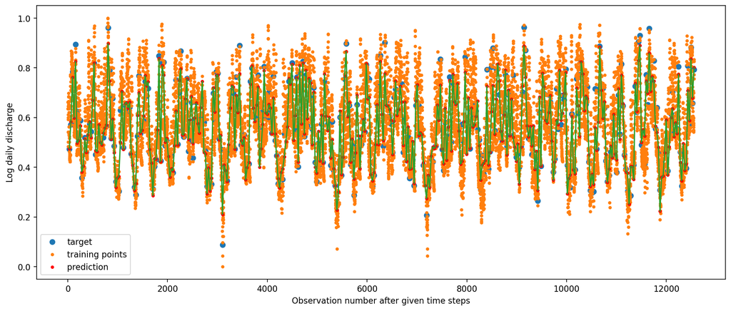

```python
# PLOT THE RESULT
def plot_result(trainY, testY, train_predict, test_predict):
    plt.figure(figsize=(15, 6), dpi=80)
    #ORIGINAL DATA
    print(X.shape,Y.shape)
    plt.plot(Y_ind, Y,'o', label='target')
    plt.plot(X_ind, X,'.', label='training points');
    plt.plot(Y_ind, train_predict,'r.', label='prediction');
    plt.plot(Y_ind, train_predict,'-');
    plt.legend()
    plt.xlabel('Observation number after given time steps')
    plt.ylabel('Log daily discharge')
    #plt.title('Actual and Predicted Values. The Red Line Separates The Training And Test Examples')
    plt.show()
plot_result(trainY, testY, train_predict, test_predict)
```

## GRU

```python
#USER PARAM
recurrent_hidden_units=3
epochs=200
f_batch=0.2    #fraction used for batch size
optimizer="RMSprop"
# max_features = 10000    #DEFINES SIZE OF VOCBULARY TO USE
# maxlen       = 250      #CUTOFF REVIEWS maxlen 20 WORDS)
batch_size   = 1000
verbose      = 0
embed_dim    = 8        #DIMENSION OF EMBEDING SPACE (SIZE OF VECTOR FOR EACH WORD)
lr           = 0.001    #LEARNING RATE
validation_split=0.2
```

### Model with L2 regulation

```python
#CREATE MODEL
model = Sequential()
#COMMENT/UNCOMMENT TO USE RNN, LSTM,GRU
# model.add(LSTM(
#model.add(SimpleRNN(
model.add(GRU(
recurrent_hidden_units,
return_sequences=False,
input_shape=(trainX.shape[1],trainX.shape[2]),
# recurrent_dropout=0.8,
recurrent_regularizer=regularizers.L2(1e-1),
activation='tanh')
          )

#NEED TO TAKE THE OUTPUT RNN AND CONVERT TO SCALAR
model.add(Dense(units=1, activation='linear'))

# COMPILE THE MODEL
model.compile(loss='MeanSquaredError', optimizer=optimizer)
model.summary()
```

```
Model: "sequential_2"
```

```
_________________________________________________________________
```

```
 Layer (type)                Output Shape              Param #
```

```
 gru (GRU)                   (None, 3)                 54
```

```
 dense_2 (Dense)             (None, 1)                 4
```

```
Total params: 58
```

```
Trainable params: 58
```

```
Non-trainable params: 0
```

```
_________________________________________________________________
```

[output not shown]

### Train model

```python
#TRAIN MODEL
history = model.fit(
trainX, trainY,
epochs=epochs,
batch_size=int(f_batch*trainX.shape[0]),
validation_split=validation_split,  # BEING "SLOPPY WITH CROSS VALIDATION" HERE FOR TIME-SERIES
verbose=0)
```

[output not shown]

[output not shown]

[output not shown]

### Visualize fitting history

[output not shown]

```
(405, 30, 1) (405,) (405,) (101, 30, 1) (101,) (101,)
(405,) (405,)
0.0021219314
0.0020427871
Train MSE = 0.00212 RMSE = 0.04606
Test MSE = 0.00204 RMSE = 0.04520
```

[interactive chart not shown]

[output not shown]

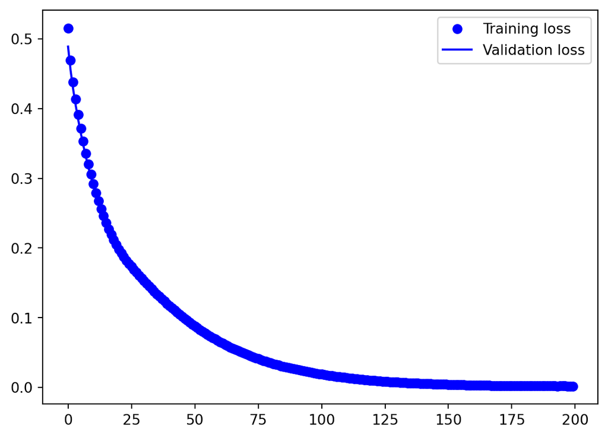

```python
#HISTORY PLOT
epochs_steps = [*range(0, len(history.history['loss']))]

# MAKE PREDICTIONS
train_predict = model.predict(trainX).squeeze()
test_predict = model.predict(testX).squeeze()
print(trainX.shape, train_predict.shape,trainY.shape,testX.shape, test_predict.shape,testY.shape)

#COMPUTE RMSE
print(trainY.shape, train_predict.shape)
train_rmse = np.sqrt(mean_squared_error(trainY, train_predict))
test_rmse = np.sqrt(mean_squared_error(testY, test_predict))
print(np.mean((trainY-train_predict)**2.0))
print(np.mean((testY-test_predict)**2.0))

print('Train MSE = %.5f RMSE = %.5f' % (train_rmse**2.0,train_rmse))
print('Test MSE = %.5f RMSE = %.5f' % (test_rmse**2.0,test_rmse))

# PLOTLY PLOT
plotly_line_plot([epochs_steps,epochs_steps],[history.history['loss'],history.history['val_loss']],title="Sunspots per month since 1749-01",x_label="training epochs",y_label="loss (MSE)")

print(history.history['loss'])
# SIMPLE PLOT
plt.figure()
plt.plot(epochs_steps, history.history['loss'], 'bo', label='Training loss')
plt.plot(epochs_steps, history.history['val_loss'], 'b', label='Validation loss')
plt.legend()
```

### Visualize parity plot

```python
# GET DATA
# GENERATE PLOTLY FIGURE

fig = px.scatter(x=trainY,y=train_predict,height=600,width=800)
fig.add_scatter(x=testY,y=test_predict,mode="markers")
fig.add_scatter(x=trainY,y=trainY, mode='lines')

fig.update_layout(
    xaxis_title="y_pred",
    yaxis_title="y_data",
    template="plotly_white",
    showlegend=False
)

fig.show()
```

[interactive chart not shown]

### Model with no regulation

```python
#CREATE MODEL
model = Sequential()
#COMMENT/UNCOMMENT TO USE RNN, LSTM,GRU
# model.add(LSTM(
#model.add(SimpleRNN(
model.add(GRU(
recurrent_hidden_units,
return_sequences=False,
input_shape=(trainX.shape[1],trainX.shape[2]),
# recurrent_dropout=0.8,
#recurrent_regularizer=regularizers.L2(1e-1),
activation='tanh')
          )

#NEED TO TAKE THE OUTPUT RNN AND CONVERT TO SCALAR
model.add(Dense(units=1, activation='linear'))

# COMPILE THE MODEL
model.compile(loss='MeanSquaredError', optimizer=optimizer)
model.summary()
```

```
Model: "sequential_3"
```

```
_________________________________________________________________
```

```
 Layer (type)                Output Shape              Param #
```

```
 gru_1 (GRU)                 (None, 3)                 54
```

```
 dense_3 (Dense)             (None, 1)                 4
```

```
Total params: 58
```

```
Trainable params: 58
```

```
Non-trainable params: 0
```

```
_________________________________________________________________
```

[output not shown]

### Train model

```python
#TRAIN MODEL
history = model.fit(
trainX, trainY,
epochs=epochs,
batch_size=int(f_batch*trainX.shape[0]),
validation_split=validation_split,  # BEING "SLOPPY WITH CROSS VALIDATION" HERE FOR TIME-SERIES
verbose=0)
```

[output not shown]

[output not shown]

[output not shown]

### Visualize fitting history

[output not shown]

```
(405, 30, 1) (405,) (405,) (101, 30, 1) (101,) (101,)
(405,) (405,)
0.001985531
0.0017872186
Train MSE = 0.00199 RMSE = 0.04456
Test MSE = 0.00179 RMSE = 0.04228
```

[interactive chart not shown]

[output not shown]

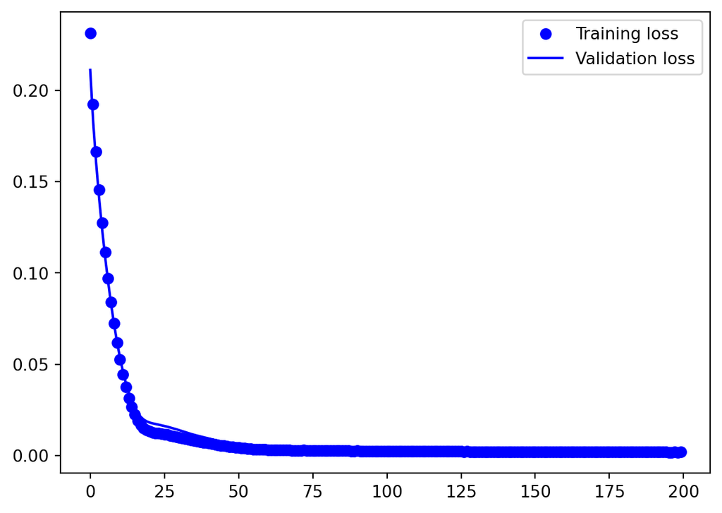

```python
#HISTORY PLOT
epochs_steps = [*range(0, len(history.history['loss']))]

# MAKE PREDICTIONS
train_predict = model.predict(trainX).squeeze()
test_predict = model.predict(testX).squeeze()
print(trainX.shape, train_predict.shape,trainY.shape,testX.shape, test_predict.shape,testY.shape)

#COMPUTE RMSE
print(trainY.shape, train_predict.shape)
train_rmse = np.sqrt(mean_squared_error(trainY, train_predict))
test_rmse = np.sqrt(mean_squared_error(testY, test_predict))
print(np.mean((trainY-train_predict)**2.0))
print(np.mean((testY-test_predict)**2.0))

print('Train MSE = %.5f RMSE = %.5f' % (train_rmse**2.0,train_rmse))
print('Test MSE = %.5f RMSE = %.5f' % (test_rmse**2.0,test_rmse))

# PLOTLY PLOT
plotly_line_plot([epochs_steps,epochs_steps],[history.history['loss'],history.history['val_loss']],title="Sunspots per month since 1749-01",x_label="training epochs",y_label="loss (MSE)")

print(history.history['loss'])
# SIMPLE PLOT
plt.figure()
plt.plot(epochs_steps, history.history['loss'], 'bo', label='Training loss')
plt.plot(epochs_steps, history.history['val_loss'], 'b', label='Validation loss')
plt.legend()
```

### Visualize parity plot

```python
# GET DATA
# GENERATE PLOTLY FIGURE

fig = px.scatter(x=trainY,y=train_predict,height=600,width=800)
fig.add_scatter(x=testY,y=test_predict,mode="markers")
fig.add_scatter(x=trainY,y=trainY, mode='lines')

fig.update_layout(
    xaxis_title="y_pred",
    yaxis_title="y_data",
    template="plotly_white",
    showlegend=False
)

fig.show()
```

[interactive chart not shown]

## LSTM

### Build model

```python
#CREATE MODEL
model = Sequential()
#COMMENT/UNCOMMENT TO USE RNN, LSTM,GRU
model.add(LSTM(
# model.add(SimpleRNN(
# model.add(GRU(
recurrent_hidden_units,
return_sequences=False,
input_shape=(trainX.shape[1],trainX.shape[2]),
# recurrent_dropout=0.8,
recurrent_regularizer=regularizers.L2(1e-1),
activation='tanh')
          )

#NEED TO TAKE THE OUTPUT RNN AND CONVERT TO SCALAR
model.add(Dense(units=1, activation='linear'))

# COMPILE THE MODEL
model.compile(loss='MeanSquaredError', optimizer=optimizer)
model.summary()
```

```
Model: "sequential_4"
```

```
_________________________________________________________________
```

```
 Layer (type)                Output Shape              Param #
```

```
 lstm (LSTM)                 (None, 3)                 60
```

```
 dense_4 (Dense)             (None, 1)                 4
```

```
Total params: 64
```

```
Trainable params: 64
```

```
Non-trainable params: 0
```

```
_________________________________________________________________
```

[output not shown]

### Model and training parameters

```python
#USER PARAM
recurrent_hidden_units=3
epochs=200
f_batch=0.2    #fraction used for batch size
optimizer="RMSprop"
validation_split=0.2
```

### Create model

```python
#CREATE MODEL
model = Sequential()
#COMMENT/UNCOMMENT TO USE RNN, LSTM,GRU
model.add(LSTM(
# model.add(SimpleRNN(
# model.add(GRU(
recurrent_hidden_units,
return_sequences=False,
input_shape=(trainX.shape[1],trainX.shape[2]),
# recurrent_dropout=0.8,
recurrent_regularizer=regularizers.L2(1e-1),
activation='tanh')
          )

#NEED TO TAKE THE OUTPUT RNN AND CONVERT TO SCALAR
model.add(Dense(units=1, activation='linear'))

# COMPILE THE MODEL
model.compile(loss='MeanSquaredError', optimizer=optimizer)
model.summary()
```

```
Model: "sequential_5"
```

```
_________________________________________________________________
```

```
 Layer (type)                Output Shape              Param #
```

```
 lstm_1 (LSTM)               (None, 3)                 60
```

```
 dense_5 (Dense)             (None, 1)                 4
```

```
Total params: 64
```

```
Trainable params: 64
```

```
Non-trainable params: 0
```

```
_________________________________________________________________
```

[output not shown]

### Train model

```python
#TRAIN MODEL
history = model.fit(
trainX, trainY,
epochs=epochs,
batch_size=int(f_batch*trainX.shape[0]),
validation_split=validation_split,  # BEING "SLOPPY WITH CROSS VALIDATION" HERE FOR TIME-SERIES
verbose=0)
```

[output not shown]

[output not shown]

[output not shown]

### Visualize fitting history

[output not shown]

```
(405, 30, 1) (405,) (405,) (101, 30, 1) (101,) (101,)
(405,) (405,)
0.004491217
0.0047633937
Train MSE = 0.00449 RMSE = 0.06702
Test MSE = 0.00476 RMSE = 0.06902
```

[interactive chart not shown]

[output not shown]

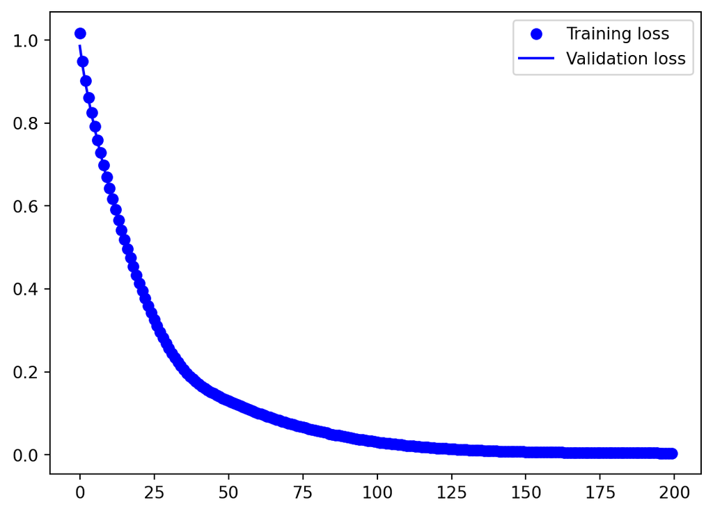

```python
#HISTORY PLOT
epochs_steps = [*range(0, len(history.history['loss']))]

# MAKE PREDICTIONS
train_predict = model.predict(trainX).squeeze()
test_predict = model.predict(testX).squeeze()
print(trainX.shape, train_predict.shape,trainY.shape,testX.shape, test_predict.shape,testY.shape)

#COMPUTE RMSE
print(trainY.shape, train_predict.shape)
train_rmse = np.sqrt(mean_squared_error(trainY, train_predict))
test_rmse = np.sqrt(mean_squared_error(testY, test_predict))
print(np.mean((trainY-train_predict)**2.0))
print(np.mean((testY-test_predict)**2.0))

print('Train MSE = %.5f RMSE = %.5f' % (train_rmse**2.0,train_rmse))
print('Test MSE = %.5f RMSE = %.5f' % (test_rmse**2.0,test_rmse))

# PLOTLY PLOT
plotly_line_plot([epochs_steps,epochs_steps],[history.history['loss'],history.history['val_loss']],title="Sunspots per month since 1749-01",x_label="training epochs",y_label="loss (MSE)")

print(history.history['loss'])
# SIMPLE PLOT
plt.figure()
plt.plot(epochs_steps, history.history['loss'], 'bo', label='Training loss')
plt.plot(epochs_steps, history.history['val_loss'], 'b', label='Validation loss')
plt.legend()
```

### Visualize parity plot

```python
# GET DATA
# GENERATE PLOTLY FIGURE

fig = px.scatter(x=trainY,y=train_predict,height=600,width=800)
fig.add_scatter(x=testY,y=test_predict,mode="markers")
fig.add_scatter(x=trainY,y=trainY, mode='lines')

fig.update_layout(
    xaxis_title="y_pred",
    yaxis_title="y_data",
    template="plotly_white",
    showlegend=False
)

fig.show()
```

[interactive chart not shown]

## Conclusion

### Comparison among ANNs

Table 1: Comparison among RNN, GRU, and LSTM

[output not shown]

### Comparison among ANNs and ARMA/ARIMA

As to compare with time-series ARMA/ARIMA models from HW-3, it really depends on our criteria. The deep learning models took more time to training compares to the traditional time series model such as ARMA/ARIMA due to more parameters in the deep learning models. However, deep learning model parameters setting are more like a black box. To tuning the parameters, cross-validation method is extensively used. ARMA/ARIMA model used ACF and PACF plots to obtain the distribution of the data, which make the models’ interpretability better than the deep leaning models.

From Table 2, we can see that the RMSEs of ANN models are significantly lower than the traditional time series models. The traditional time series model with lowest RMSE is the SARIMA(2,1,1,0,1,1) model. The RMSE is around 0.7, while the ANN model with lowest RMSE is RNN with L2 regularization with RMSE of 0.04.

When choosing traditional time series models, we used AIC, while for the deep learning models, we use MSE/RMSE to chose the best model. This may also slightly affect that in terms of RMSE, traditional time series models perform not good. a In terms of MSE/RMSE, deep learning modes perform better than the ARMA/ARIMA models. We can also draw this conclusion from the prediction in [ARIMAX/SARIMAX/VAR Models](https://xni.georgetown.domains/timeseries560/arma_arima_sarima.html), [ARIMAX/SARIMAX/VAR Models](https://xni.georgetown.domains/timeseries560/ARIMAX_SARIMAX_VAR.html) and the parity plots above.

Table 2: Comparison of RMSE among ARIMA, SARIMA, VAR(3), RNN, GRU, and LSTM.

[output not shown]